# Discussion 9: Qualitative Predictors

Christine Cai

March 1, 2016

```r
dat = read.table('CH08PR24.txt')
names(dat) = c('y', 'x1', 'x2')
head(dat)
```

```
##      y   x1 x2
## 1 78.8 76.4  0
## 2 73.8 74.3  0
## 3 64.6 69.6  0
## 4 76.2 73.6  0
## 5 87.2 76.8  0
## 6 70.6 72.7  1
```

As usual, `y` is the response. However, while `x1` is a quantitative predictor, `x2` is a qualitative predictor. Problem 8.24 in your text describes the 2 levels of `x2` as 2 ‘populations’. Suppose we want to plot the data, while making a clear distinction between the 2 populations.

We want to split `dat` into the groups defined by `x2`. `?split`

```r
dat.spl = split(dat, dat$x2); dat.spl
```

```
## $`0`
##       y   x1 x2
## 1  78.8 76.4  0
## 2  73.8 74.3  0
## 3  64.6 69.6  0
## 4  76.2 73.6  0
## 5  87.2 76.8  0
## 7  86.0 79.2  0
## 8  83.1 75.6  0
## 9  94.5 78.1  0
## 11 64.3 68.5  0
## 12 73.1 73.2  0
## 13 96.8 77.5  0
## 14 82.4 76.2  0
## 15 81.6 75.1  0
```

[output cut: 54 more lines]

`dat.spl` is a list, so we can access its elements with `[[ ]]` or by their names. Let’s try plotting `y` vs `x1` for `x2 = 0`.

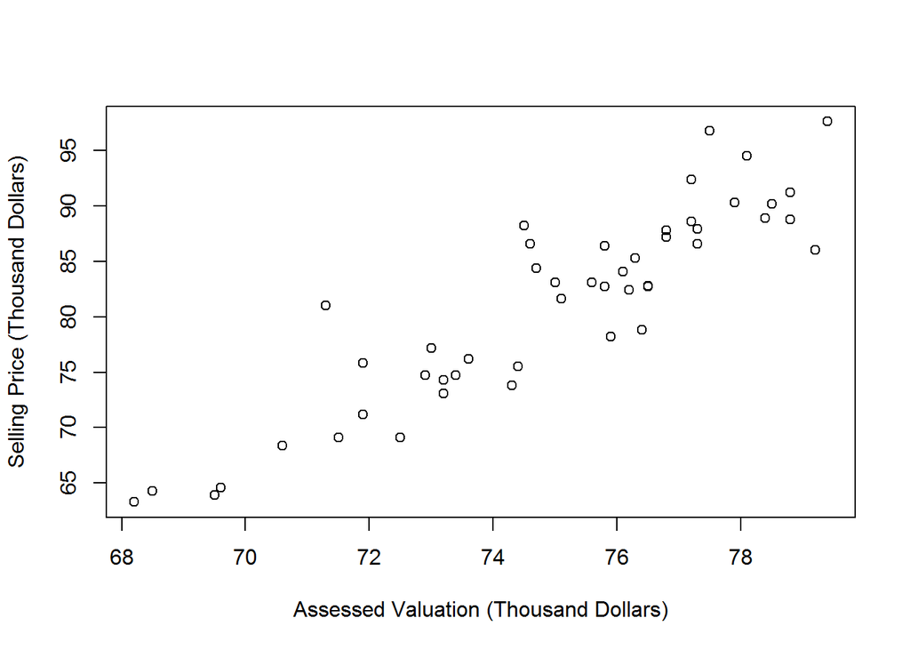

```r
plot(dat.spl[[1]]$x1, dat.spl$'0'$y,
     xlab = 'Assessed Valuation (Thousand Dollars)',
     ylab = 'Selling Price (Thousand Dollars)')
```

Or equivalently,

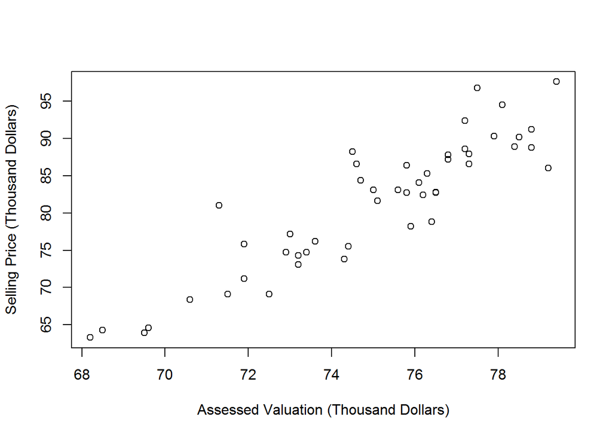

```r
with(dat.spl$'0', plot(x1, y,
     xlab = 'Assessed Valuation (Thousand Dollars)',
     ylab = 'Selling Price (Thousand Dollars)'))
```

The `with()` command tells R to look for any objects in our function call (`plot()`) under the environment we give (`dat.spl$'0'`).

We also want to plot `y` vs `x1` for `x2 = 1`. But we want these points to be on the same plot. Recall the function `points()`,

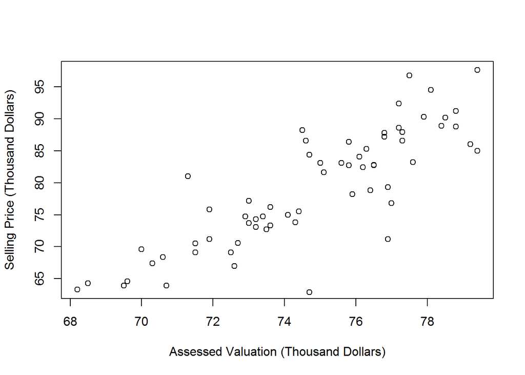

```r
with(dat.spl$'0', plot(x1, y,
     xlab = 'Assessed Valuation (Thousand Dollars)',
     ylab = 'Selling Price (Thousand Dollars)'))
with(dat.spl$'1', points(x1, y))
```

Note that we can’t tell which points correspond to `x2 = 0` and which correspond to `x2 = 1`. You may choose to distinguish the 2 populations by using different plotting characters, colors, or both. If you don’t have access to a color printer, then you must use different plotting characters.

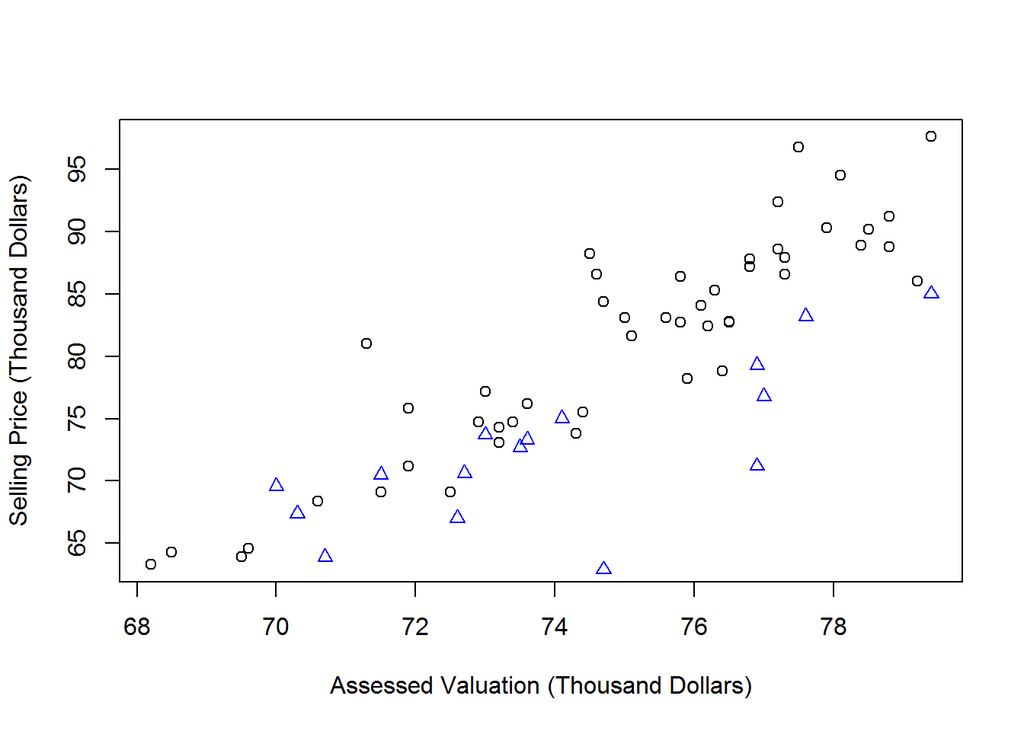

```r
with(dat.spl$'0', plot(x1, y,
     xlab = 'Assessed Valuation (Thousand Dollars)',
     ylab = 'Selling Price (Thousand Dollars)'))
with(dat.spl$'1', points(x1, y, pch = 2, col = 'blue'))
```

The original plotting window was determined by the points corresponding to `x2 = 0`, so some points corresponding to `x2 = 1` may be outside of that window and are not plotted. To ensure that the original plotting window will include all the points, we need to define our own x and y limits in the first `plot()` command. The `xlim` needs to be the range of the `x1` vector in the original `dat`. Similarly, `ylim` needs to be the range of the `y` vector in the original `dat`.

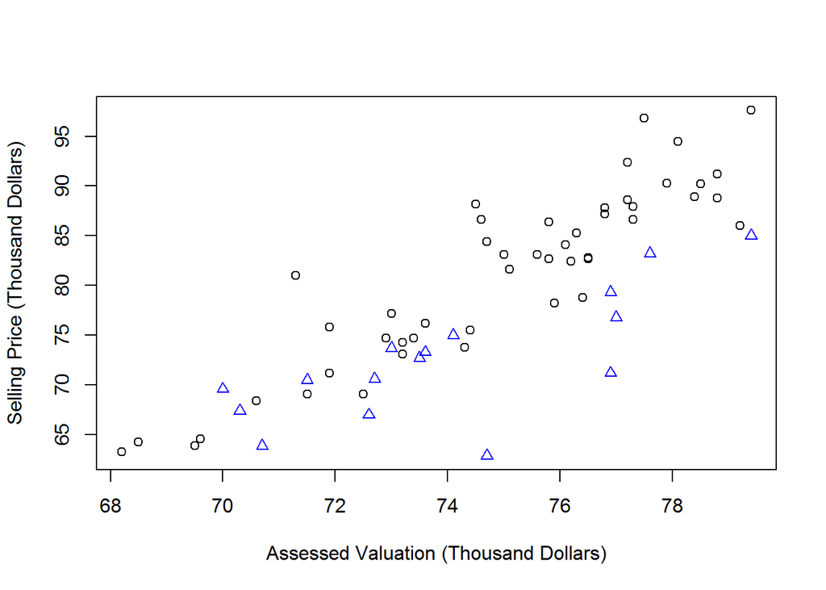

```r
with(dat.spl$'0', plot(x1, y,
     xlab = 'Assessed Valuation (Thousand Dollars)',
     ylab = 'Selling Price (Thousand Dollars)',
     xlim = range(dat$x1), ylim = range(dat$y)))
with(dat.spl$'1', points(x1, y, pch = 2, col = 'blue'))
```

The last thing we need to do for this plot is to include a legend. `?legend`

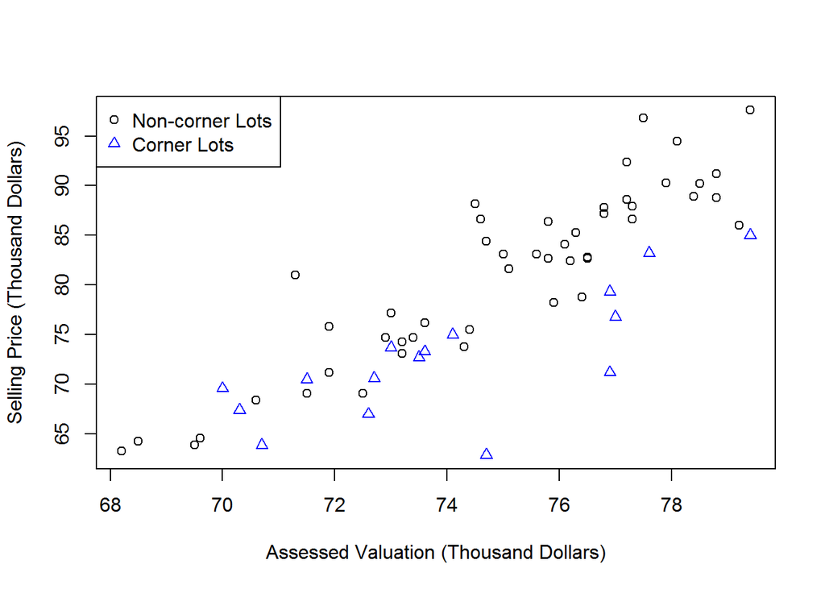

```r
with(dat.spl$'0', plot(x1, y,
     xlab = 'Assessed Valuation (Thousand Dollars)',
     ylab = 'Selling Price (Thousand Dollars)',
     xlim = range(dat$x1), ylim = range(dat$y)))
with(dat.spl$'1', points(x1, y, pch = 2, col = 'blue'))
legend('topleft', legend = c('Non-corner Lots', 'Corner Lots'),
       pch = 1:2, col = c(1, 'blue'))
```

Just as with a function like `points()`, `legend()` appends to the last plot created.

Now suppose we want to add the estimated regression functions for the 2 populations to our plot. First, fit 2 separate regressions for the 2 populations.

```r
fit0 = lm(y ~ x1, data = dat.spl$'0'); fit0
```

```
##
## Call:
## lm(formula = y ~ x1, data = dat.spl$"0")
##
## Coefficients:
## (Intercept)           x1
##    -126.905        2.776
```

```r
fit1 = lm(y ~ x1, data = dat.spl$'1'); fit1
```

```
##
## Call:
## lm(formula = y ~ x1, data = dat.spl$"1")
##
## Coefficients:
## (Intercept)           x1
##     -50.884        1.668
```

Add the first regression line,

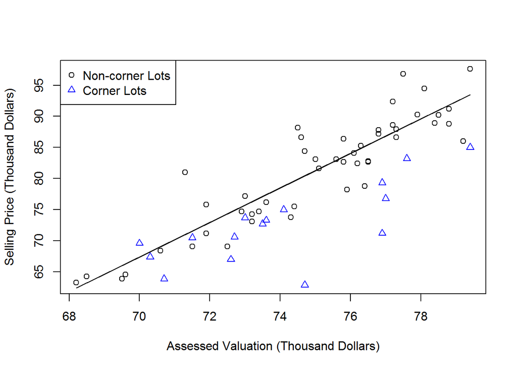

```r
with(dat.spl$'0', plot(x1, y,
     xlab = 'Assessed Valuation (Thousand Dollars)',
     ylab = 'Selling Price (Thousand Dollars)',
     xlim = range(dat$x1), ylim = range(dat$y)))
with(dat.spl$'1', points(x1, y, pch = 2, col = 'blue'))
legend('topleft', legend = c('Non-corner Lots', 'Corner Lots'),
       pch = 1:2, col = c(1, 'blue'))
points(dat.spl$'0'$x1, fit0$fit, type = 'l')
```

```r
head(dat)
```

```
##      y   x1 x2
## 1 78.8 76.4  0
## 2 73.8 74.3  0
## 3 64.6 69.6  0
## 4 76.2 73.6  0
## 5 87.2 76.8  0
## 6 70.6 72.7  1
```

So when R is plotting the points in a line, it is zigzagging back and forth instead of connecting points in order. To fix this, we need the order in which the rows should occur if `x1` is in increasing order. Note that since each row of `dat` is one observation, we cannot just sort `x1`. Instead, we need to sort the rows of `dat` in increasing order of `x1`.

```r
ind = order(dat$x1); ind
```

```
##  [1] 59 11 57  3 27 42 43 33 55 26 64 28 46 40 31  6 37 17 18 12 61 20 48
## [24]  4 38 41  2 54 56 51 29 63 39 15  8 45 50 58 30 14 34  1 23 52  5 24
## [47] 10 44 16 19 35 22 53 13 32 36  9 49 60 21 47  7 25 62
```

The above means that row 59 of `dat` contains the smallest value for `x1`, followed by row 11, 57, and so on. Row 62 of `dat` contains the largest `x1`. So now we just need to rearrange the rows of `dat` according to the above order we found.

```r
dat = dat[ind,]; head(dat)
```

```
##       y   x1 x2
## 59 63.3 68.2  0
## 11 64.3 68.5  0
## 57 63.9 69.5  0
## 3  64.6 69.6  0
## 27 69.6 70.0  1
## 42 67.4 70.3  1
```

Now we need to rerun our code with this newly sorted `dat`.

```r
dat.spl = split(dat, dat$x2); dat.spl
```

```
## $`0`
##       y   x1 x2
## 59 63.3 68.2  0
## 11 64.3 68.5  0
## 57 63.9 69.5  0
## 3  64.6 69.6  0
## 43 68.4 70.6  0
## 55 81.0 71.3  0
## 26 69.1 71.5  0
## 28 71.2 71.9  0
## 46 75.8 71.9  0
## 40 69.1 72.5  0
## 37 74.7 72.9  0
## 17 77.2 73.0  0
## 12 73.1 73.2  0
```

[output cut: 54 more lines]

```r
fit0 = lm(y ~ x1, data = dat.spl$'0'); fit0
```

```
##
## Call:
## lm(formula = y ~ x1, data = dat.spl$"0")
##
## Coefficients:
## (Intercept)           x1
##    -126.905        2.776
```

```r
fit1 = lm(y ~ x1, data = dat.spl$'1'); fit1
```

```
##
## Call:
## lm(formula = y ~ x1, data = dat.spl$"1")
##
## Coefficients:
## (Intercept)           x1
##     -50.884        1.668
```

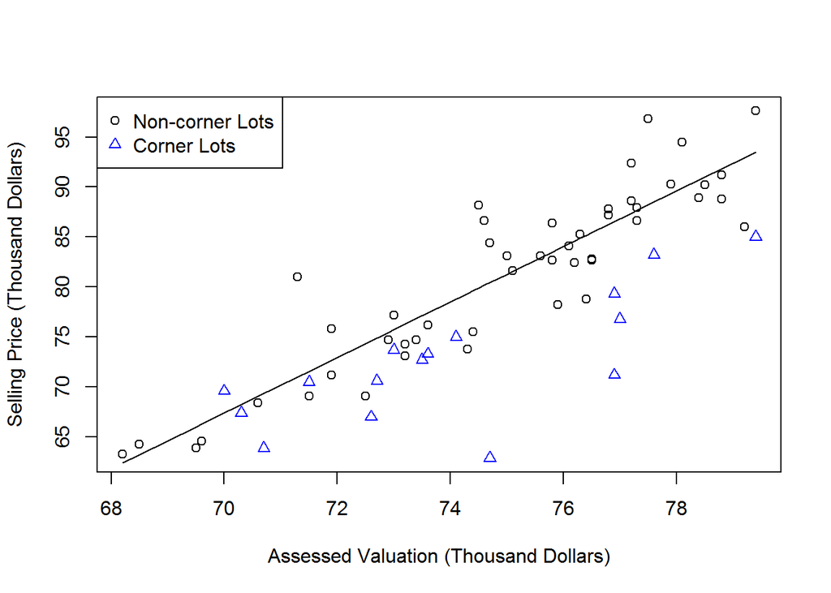

```r
with(dat.spl$'0', plot(x1, y,
     xlab = 'Assessed Valuation (Thousand Dollars)',
     ylab = 'Selling Price (Thousand Dollars)',
     xlim = range(dat$x1), ylim = range(dat$y)))
with(dat.spl$'1', points(x1, y, pch = 2, col = 'blue'))
legend('topleft', legend = c('Non-corner Lots', 'Corner Lots'),
       pch = 1:2, col = c(1, 'blue'))
points(dat.spl$'0'$x1, fit0$fit, type = 'l')
```

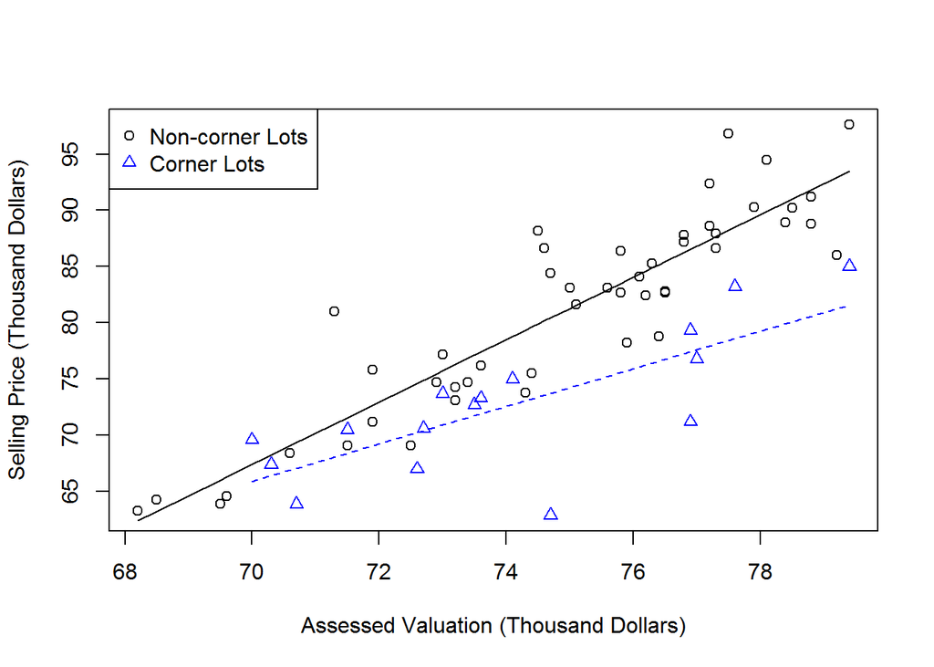

```r
with(dat.spl$'0', plot(x1, y,
     xlab = 'Assessed Valuation (Thousand Dollars)',
     ylab = 'Selling Price (Thousand Dollars)',
     xlim = range(dat$x1), ylim = range(dat$y)))
with(dat.spl$'1', points(x1, y, pch = 2, col = 'blue'))
legend('topleft', legend = c('Non-corner Lots', 'Corner Lots'),
       pch = 1:2, col = c(1, 'blue'))
points(dat.spl$'0'$x1, fit0$fit, type = 'l')
points(dat.spl$'1'$x1, fit1$fit, type = 'l', lty = 2, col = 'blue')
```

Lastly, let’s change the `legend()` command to account for the added regression lines.

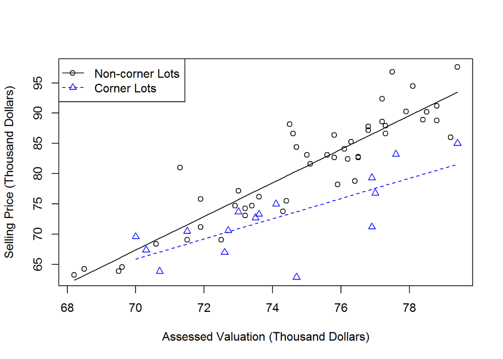

```r
with(dat.spl$'0', plot(x1, y,
     xlab = 'Assessed Valuation (Thousand Dollars)',
     ylab = 'Selling Price (Thousand Dollars)',
     xlim = range(dat$x1), ylim = range(dat$y)))
with(dat.spl$'1', points(x1, y, pch = 2, col = 'blue'))
points(dat.spl$'0'$x1, fit0$fit, type = 'l')
points(dat.spl$'1'$x1, fit1$fit, type = 'l', lty = 2, col = 'blue')
legend('topleft', legend = c('Non-corner Lots', 'Corner Lots'),
       pch = 1:2, col = c(1, 'blue'), lty = 1:2)
```

### Model Fitting

To fit $Y_i = \beta_0 + \beta_1 X_1 + \beta_2 X_2 + \beta_3 X_1 X_2 + \varepsilon_i$,

```r
fit = lm(y ~ x1*as.factor(x2), data = dat)
summary(fit)
```

```
##
## Call:
## lm(formula = y ~ x1 * as.factor(x2), data = dat)
##
## Residuals:
##      Min       1Q   Median       3Q      Max
## -10.8470  -2.1639   0.0913   1.9348   9.9836
##
## Coefficients:
##                    Estimate Std. Error t value Pr(>|t|)
## (Intercept)       -126.9052    14.7225  -8.620 4.33e-12 ***
## x1                   2.7759     0.1963  14.142  < 2e-16 ***
## as.factor(x2)1      76.0215    30.1314   2.523  0.01430 *
## x1:as.factor(x2)1   -1.1075     0.4055  -2.731  0.00828 **
## ---
## Signif. codes:  0 '***' 0.001 '**' 0.01 '*' 0.05 '.' 0.1 ' ' 1
##
## Residual standard error: 3.893 on 60 degrees of freedom
## Multiple R-squared:  0.8233, Adjusted R-squared:  0.8145
## F-statistic: 93.21 on 3 and 60 DF,  p-value: < 2.2e-16
```

```r
anova(fit)
```

```
## Analysis of Variance Table
##
## Response: y
##                  Df Sum Sq Mean Sq  F value    Pr(>F)
## x1                1 3670.9  3670.9 242.2760 < 2.2e-16 ***
## as.factor(x2)     1  453.1   453.1  29.9073 9.282e-07 ***
## x1:as.factor(x2)  1  113.0   113.0   7.4578  0.008281 **
## Residuals        60  909.1    15.2
## ---
## Signif. codes:  0 '***' 0.001 '**' 0.01 '*' 0.05 '.' 0.1 ' ' 1
```